# Evaluations of positive and negative stimuli using the Affective Misattribution Procedure (AMP) and self-reports

Analysis

03 Januar, 2024

# Dependencies

```r
library(tidyverse)
library(knitr)
library(kableExtra)
library(janitor)
library(scales)
library(PupillometryR)
library(palmerpenguins)
library(ggdist)
library(ggExtra)
library(ggrepel)
library(remotes)
library(ggthemes)
library(ggsci)
# devtools::install_github("psyteachr/introdataviz")
```

# Data

Load the processed data and apply the global exclusions.

```r
data_processed <- read_csv("../data/processed/data_processed.csv")

data_processed_after_exclusions <- data_processed |>
  filter(exclude_participant == "include")
```

# Sample descriptives

## Sample size before exclusions

```r
data_processed |>
  count(name = "n") |>
  kable() |>
  add_header_above(header = c("Whole sample" = 1)) |> # note that you can add header rows to tables like this. The "1" indicates the number of columns the header should span. The sum of these numbers must equal the number of columns or you'll get an error.
  kable_classic(full_width = FALSE)
```

| Whole sample n |
| --- |
| 102 |

## Sample size after exclusions

Sample used in subsequent analyses

```r
data_processed_after_exclusions |>
  count(name = "n") |>
  kable() |>
  add_header_above(header = c("For analysis" = 1)) |>
  kable_classic(full_width = FALSE)
```

| For analysis n |
| --- |
| 90 |

## Age

```r
data_processed_after_exclusions |>
  mutate(age = as.numeric(age)) |>
  summarise(Mean = mean(age, na.rm = TRUE),
            SD = sd(age, na.rm = TRUE)) |>
  mutate_all(.funs = janitor::round_half_up, digits = 1) |>
  kable() |>
  add_header_above(header = c("Age" = 2)) |>
  kable_classic(full_width = FALSE)
```

| Age Mean | Age SD |
| --- | --- |
| 36.8 | 12.4 |

## Gender

```r
data_processed_after_exclusions |>
  rename(Gender = gender) |>
  group_by(Gender) |>
  summarise(n = n()) |>
  mutate(Percent = paste0(round_half_up((n / sum(n)) * 100, 1), "%")) |>
  mutate(Gender = stringr::str_to_sentence(Gender)) |> # Change the case of the Gender variable so that it prints nicely
  kable() |>
  kable_classic(full_width = FALSE)
```

| Gender | n | Percent |
| --- | --- | --- |
| Female | 39 | 43.3% |
| Male | 48 | 53.3% |
| Nonbinary | 3 | 3.3% |

# Descriptives

Descriptive statistics and plots of the measures (excluding the demographics variables)

## Self-reported evaluations

### Descriptive stats

```r
# overall self-reported evaluations
dat_mean_ratings <- data_processed_after_exclusions |>
  summarise(Mean = mean(mean_evaluation, na.rm = TRUE),
            SD = sd(mean_evaluation, na.rm = TRUE),
            n = n()) |>
  mutate(group = "Full sample")

# self-reported evaluations by gender category
dat_mean_ratings_by_gender <- data_processed_after_exclusions |>
  group_by(group = gender) |>
  summarise(Mean = mean(mean_evaluation, na.rm = TRUE),
            SD = sd(mean_evaluation, na.rm = TRUE),
            n = n())

# combine both into one table
bind_rows(dat_mean_ratings,
          dat_mean_ratings_by_gender) |>
  select(Subset = group, Mean, SD, n) |> # select variables of interest, and rename one
  mutate(Subset = stringr::str_to_sentence(Subset)) |> # Change the case of the Subset variable so that it prints nicely
  mutate_if(is.numeric, round_half_up, digits = 2) |>
  kable() |>
  add_header_above(header = c(" " = 1, "Self-reported evaluations" = 3)) |>
  kable_classic(full_width = FALSE)
```

| Subset | Self-reported evaluations Mean | Self-reported evaluations SD | Self-reported evaluations n |
| --- | --- | --- | --- |
| Full sample | 1.64 | 1.02 | 90 |
| Female | 1.32 | 0.71 | 39 |
| Male | 1.81 | 1.03 | 48 |
| Nonbinary | 3.33 | 2.19 | 3 |

### Descriptive plot

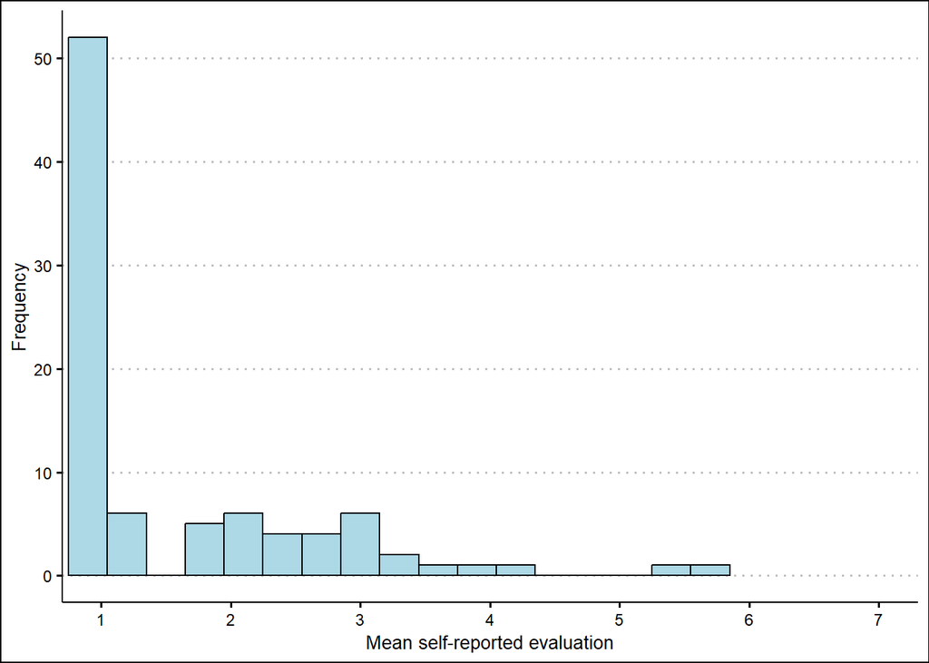

```r
ggplot(data_processed_after_exclusions, aes(x = mean_evaluation)) +
  geom_histogram(binwidth = 0.3,
                 fill =  "lightblue",
                 color = "black") +
  xlab("Mean self-reported evaluation") +
  ylab("Frequency") +
  theme_linedraw() +
  scale_x_continuous(breaks = pretty_breaks(n = 7)) +
  coord_cartesian(xlim = c(1, 7)) +
  theme_clean()
```

## AMP evaluations

### Descriptive stats

add table of means, SDs, Ns

```r
# overall AMP score
dat_amp_score <- data_processed_after_exclusions |>
  summarise(Mean = mean(AMP_score, na.rm = TRUE),
            SD = sd(AMP_score, na.rm = TRUE),
            n = n()) |>
  mutate(group = "Full sample")

# self-reported evaluations by gender category
dat_amp_score_by_gender <- data_processed_after_exclusions |>
  group_by(group = gender) |>
  summarise(Mean = mean(AMP_score, na.rm = TRUE),
            SD = sd(AMP_score, na.rm = TRUE),
            n = n())

# combine both into one table
bind_rows(dat_amp_score,
          dat_amp_score_by_gender) |>
  select(Subset = group, Mean, SD, n) |> # select variables of interest, and rename one
  mutate(Subset = stringr::str_to_sentence(Subset)) |> # Change the case of the Subset variable so that it prints nicely
  mutate_if(is.numeric, round_half_up, digits = 2) |>
  kable() |>
  add_header_above(header = c(" " = 1, "Self-reported evaluations" = 3)) |>
  kable_classic(full_width = FALSE)
```

[output not shown]

### Descriptive plots

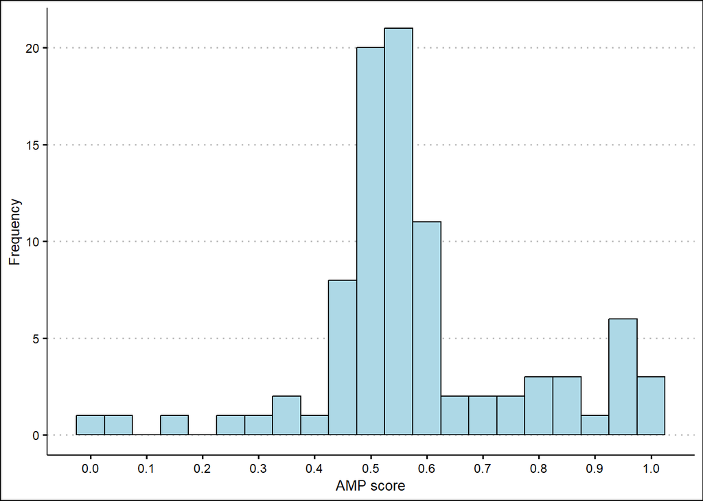

```r
ggplot(data_processed_after_exclusions, aes(x = AMP_score)) +
  geom_histogram(binwidth = 0.05,
                 fill =  "lightblue",
                 color = "black") +
  scale_colour_viridis_d(option = "plasma") +
  scale_x_continuous(breaks = pretty_breaks(n = 10)) +
  xlab("AMP score") +
  ylab("Frequency") +
  theme_clean()
```

# Analyses & hypothesis tests

## Self-reported evaluations are correlated with evaluations on the AMP

### Plot

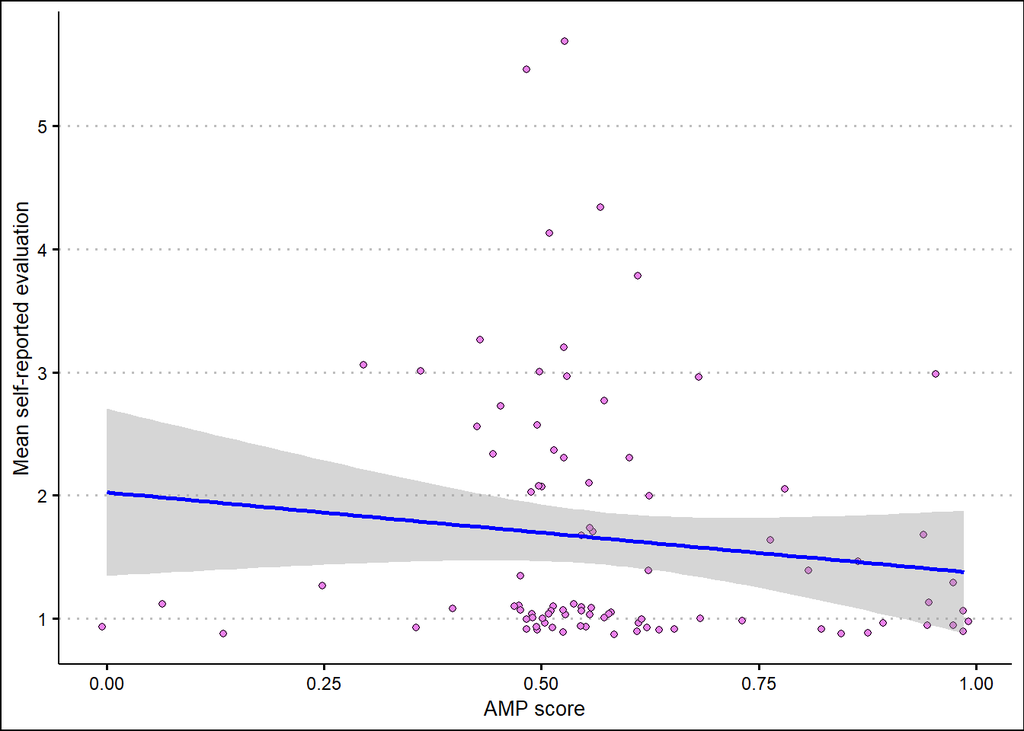

```r
ggplot(data_processed_after_exclusions, aes(x = AMP_score, y = mean_evaluation)) +
  geom_jitter(shape = 21,
              color = "black",
              alpha = 1,
              fill = "violet") +
  geom_smooth(method = "lm",
              color = "blue") +
  xlab("AMP score") +
  ylab("Mean self-reported evaluation") +
  theme_clean()
```

More complex plots:

#### Axial hisograms

Scatter plots with axial histograms using ggExtra: https://cran.r-project.org/web/packages/ggExtra/vignettes/ggExtra.html

add axial histograms to a scatter plot. Split both the scatter plot and the histograms by gender. # move legend location!!!!!!!!!!

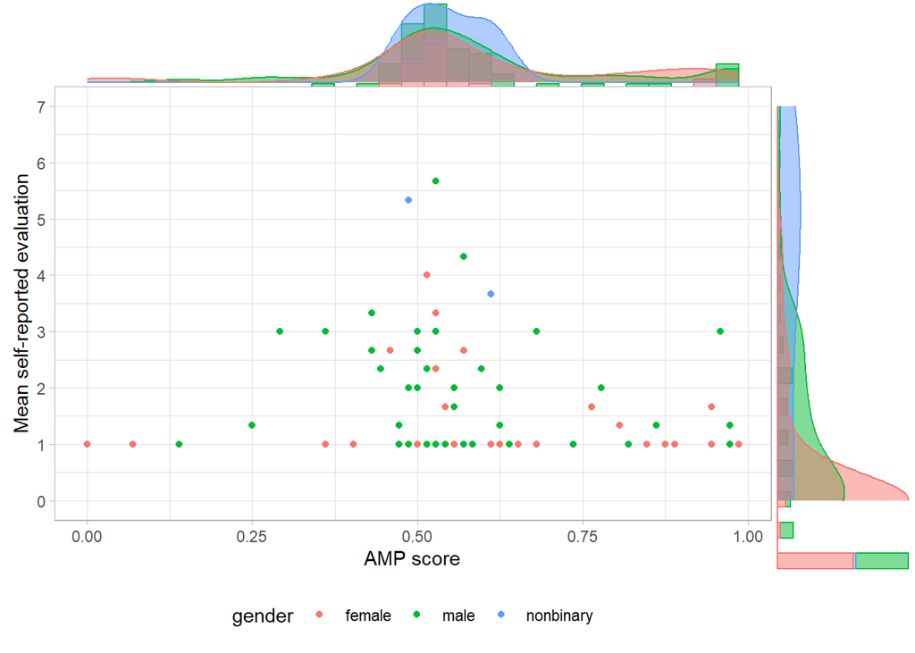

```r
# move legend location!!!!!!!

piris <- ggplot(data_processed_after_exclusions, aes(x = AMP_score, y = mean_evaluation, colour = gender)) +
  geom_point() +
  scale_y_continuous(breaks = pretty_breaks(n = 7)) +
  coord_cartesian(ylim = c(0, 7)) +
  xlab("AMP score") +
  ylab("Mean self-reported evaluation") +
  theme_light()+
  theme(legend.position = c(0.125,.7))

piris2 <- ggplot(data_processed_after_exclusions, aes(x = AMP_score, y = mean_evaluation, colour = gender)) +
  geom_point() +
  scale_y_continuous(breaks = pretty_breaks(n = 7)) +
  coord_cartesian(ylim = c(0, 7)) +
  xlab("AMP score") +
  ylab("Mean self-reported evaluation") +
  theme_light()+
  theme(legend.position = "bottom")

ggMarginal(piris, type = "histogram",groupColour = TRUE, groupFill = TRUE)
ggMarginal(piris2, groupColour = TRUE, groupFill = TRUE)
```

[output not shown]

#### Labelled points

Label points using ggrepel: https://cran.r-project.org/web/packages/ggrepel/vignettes/ggrepel.html

Label the points in a scatter plot using their participant codes.

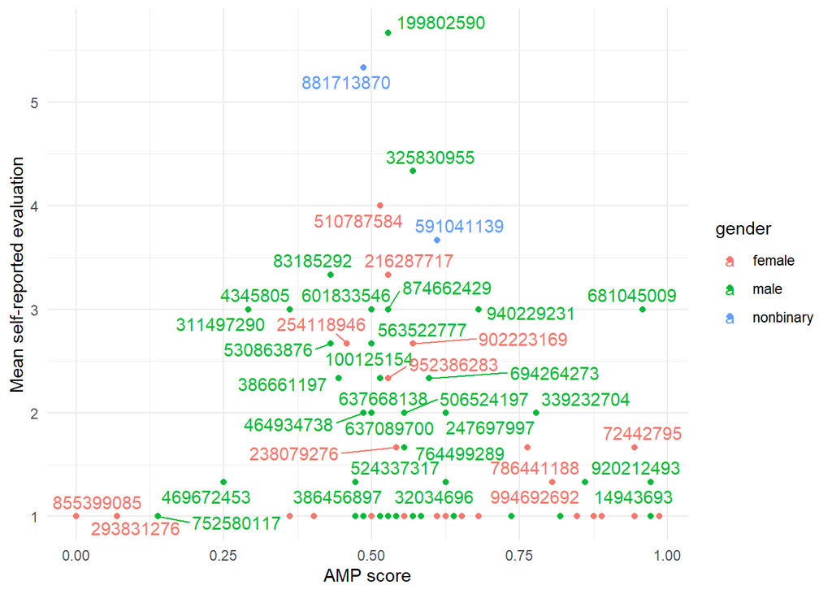

```r
# repel <-
ggplot(data_processed_after_exclusions, aes(x = AMP_score, y = mean_evaluation, label = subject, colour = gender)) +
  geom_point() +
  theme_minimal() +
  xlab("AMP score") +
  ylab("Mean self-reported evaluation") +
  geom_text_repel()
```

#### Magnify areas

Magnify areas of your plot with ggmagnify: https://hughjonesd.github.io/ggmagnify/

Magnify an area of one of your scatter plots, eg., where there are a lot of data points in a small area.

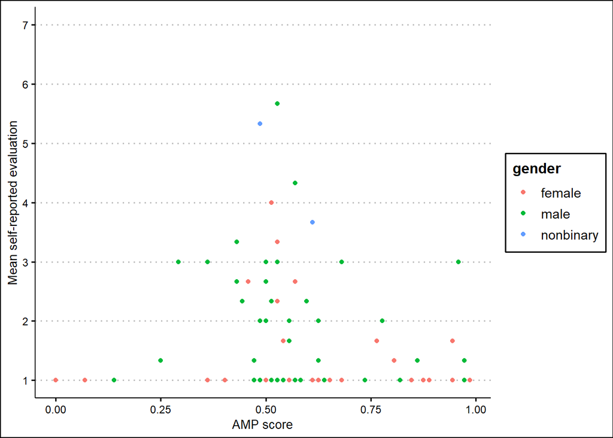

```r
# install.packages("remotes")
# remotes::install_github("hughjonesd/ggmagnify")

# Alternatively, install ggmagnify from r-universe:

# install.packages("ggmagnify", repos = c("https://hughjonesd.r-universe.dev",
#                  "https://cloud.r-project.org"))

library(ggmagnify)

ggp <- ggplot(data_processed_after_exclusions, aes(AMP_score, mean_evaluation, label = subject, colour = gender)) +
  geom_point() +
  scale_y_continuous(breaks = pretty_breaks(n = 7)) +
  coord_cartesian(ylim = c(1, 7)) +
  xlab("AMP score") +
  ylab("Mean self-reported evaluation") +
  theme_clean()#+
  # geom_text_repel()

ggp
```

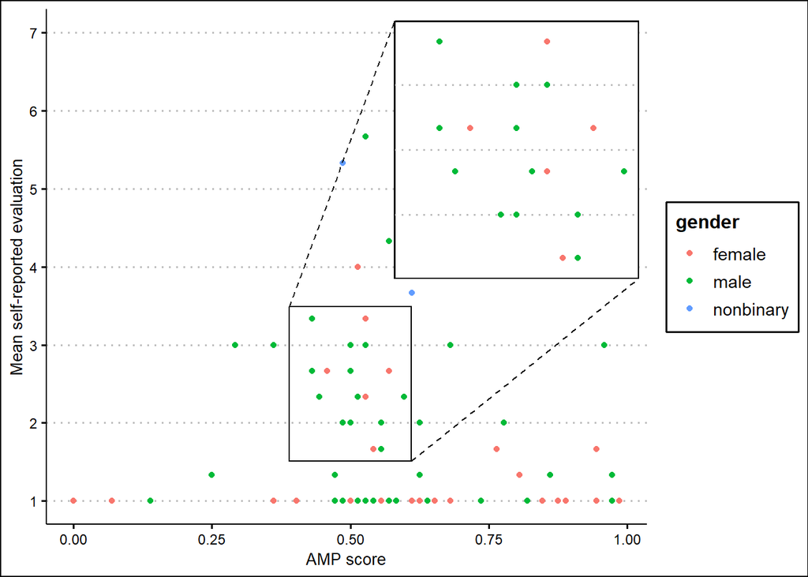

```r
from <- c(xmin = 0.4, xmax = 0.6, ymin = 1.6, ymax = 3.4)
# Names xmin, xmax, ymin, ymax are optional:
to <- c(0.6,  1, 4, 7)

ggp + geom_magnify(from = from, to = to)
```

### Test

run an appropriate test. Below the output, interpret the results: write a few sentences that report and interpret the results following APA reporting style.

```r
# Fit the linear model
model_mean_amp <- lm(mean_evaluation ~ AMP_score, data = data_processed_after_exclusions)
summary(model_mean_amp)
```

```
##
## Call:
## lm(formula = mean_evaluation ~ AMP_score, data = data_processed_after_exclusions)
##
## Residuals:
##     Min      1Q  Median      3Q     Max
## -1.0258 -0.6776 -0.4614  0.3725  3.9868
##
## Coefficients:
##             Estimate Std. Error t value   Pr(>|t|)
## (Intercept)   2.0258     0.3420   5.923 0.00000006 ***
## AMP_score    -0.6555     0.5582  -1.174      0.244
## ---
## Signif. codes:  0 '***' 0.001 '**' 0.01 '*' 0.05 '.' 0.1 ' ' 1
##
## Residual standard error: 1.017 on 88 degrees of freedom
## Multiple R-squared:  0.01542,    Adjusted R-squared:  0.004236
## F-statistic: 1.379 on 1 and 88 DF,  p-value: 0.2435
```

I performed a linear regression analysis to see whether there was a correlation between mean evaluation and AMP score. The results show that there isn’t any relation between the two variables (p > 0.05). Furthermore, the model does not seem to explain very little variance for mean evaluation.

## Self-reported evalautions differ between men and women

### Plot

split histogram, split violin plot, raincloud plot, etc.

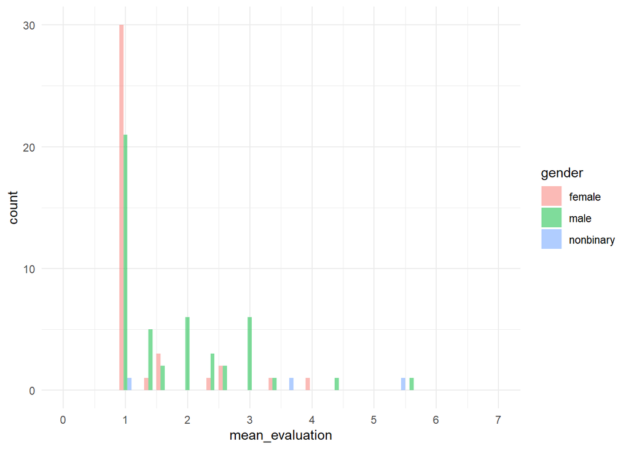

```r
#histogramm

ggplot(data_processed_after_exclusions, aes(x = mean_evaluation, fill = gender)) +
  geom_histogram(alpha    = 0.5,
                 position = "dodge",
                 binwidth = .2)+
                 # alpha    = 0.5,
                 # position = "dodge") +
  scale_x_continuous(breaks = pretty_breaks(n = 7)) +
  coord_cartesian(xlim = c(0, 7)) +
  theme_minimal()
```

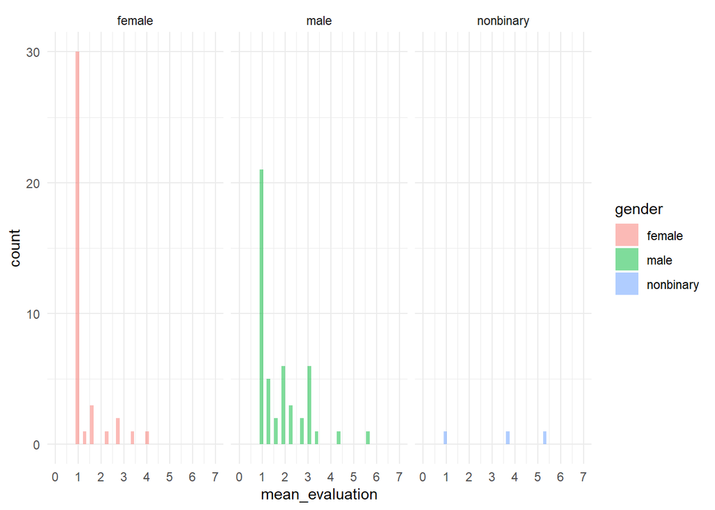

```r
ggplot(data_processed_after_exclusions, aes(x = mean_evaluation, fill = gender)) +
  geom_histogram(alpha    = 0.5,
                  position = "dodge",
                 )+#binwidth = 5,
                 # alpha    = 0.5,
                 # position = "dodge") +
  scale_x_continuous(breaks = pretty_breaks(n = 7)) +
  coord_cartesian(xlim = c(0, 7)) +
  facet_grid(~gender)+
  theme_minimal()
```

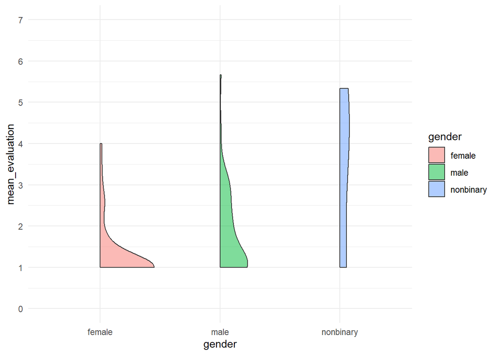

```r
#violin

ggplot(data_processed_after_exclusions, aes(x    = gender, y    = mean_evaluation, fill = gender)) +
  geom_flat_violin(draw_quantiles = .5,
              trim           = TRUE,
              alpha          = 0.5,) +
  scale_y_continuous(breaks  = pretty_breaks(n = 7)) +
  coord_cartesian(ylim       = c(0, 7)) +
  theme_minimal()
```

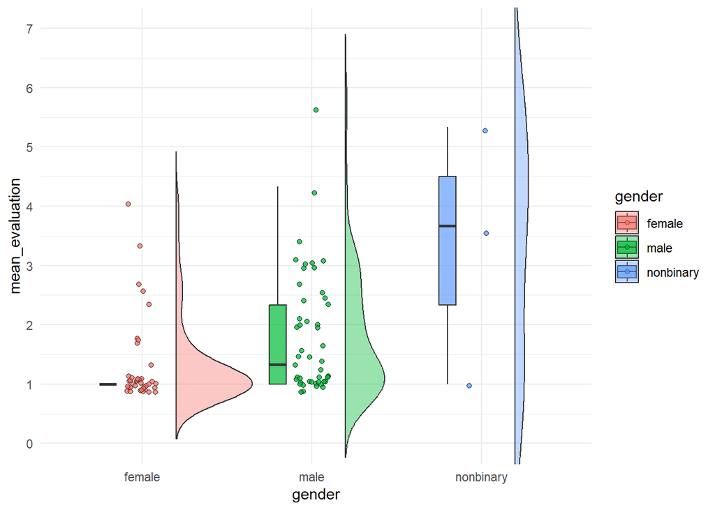

```r
#raincloud

ggplot(data_processed_after_exclusions, aes(x = gender, y = mean_evaluation, fill = gender)) +
  geom_boxplot(width         = 0.1,
               outlier.shape = NA,
               position      = position_nudge(x      = -0.2),
               alpha         = .7) +
  geom_point(position        = position_jitter(width = .1),
             aes(color       = gender),
             alpha           = .75,
             color           = "black",
             shape           = 21) +
  geom_flat_violin(trim=FALSE,
                   alpha = 0.4,
                   position = position_nudge(x = .2)) +
  scale_y_continuous(breaks  = pretty_breaks(n = 7)) +
  coord_cartesian(ylim       = c(0, 7)) +
  theme_minimal()
```

### Test

run an appropriate test. Below the output, interpret the results: write a few sentences that report and interpret the results following APA reporting style.

```r
data_processed_after_exclusions$gender_numeric <- ifelse(data_processed_after_exclusions$gender == "male", 1, 0)

# Fit the linear model
model_gender <- lm(mean_evaluation ~ gender_numeric, data = data_processed_after_exclusions)
summary(model_gender)
```

```
##
## Call:
## lm(formula = mean_evaluation ~ gender_numeric, data = data_processed_after_exclusions)
##
## Residuals:
##     Min      1Q  Median      3Q     Max
## -0.8056 -0.4722 -0.4603  0.2063  3.8730
##
## Coefficients:
##                Estimate Std. Error t value            Pr(>|t|)
## (Intercept)      1.4603     0.1558   9.372 0.00000000000000702 ***
## gender_numeric   0.3452     0.2134   1.618               0.109
## ---
## Signif. codes:  0 '***' 0.001 '**' 0.01 '*' 0.05 '.' 0.1 ' ' 1
##
## Residual standard error: 1.01 on 88 degrees of freedom
## Multiple R-squared:  0.02889,    Adjusted R-squared:  0.01786
## F-statistic: 2.618 on 1 and 88 DF,  p-value: 0.1092
```

I also performed a linear regression test here to see whether there is a difference between gender in mean evaluation. There although the males have a higher average there seems to be no difference between the two genders (p > .109).

## Evaluations on the Affect Misattribution Procedure differ between men and women

### Plot

split histogram, split violin plot, raincloud plot, etc.

This time, vary the labeling and order of the legend, e.g., capitalise “Men” and “Women”, and know how to change the order of the factors.

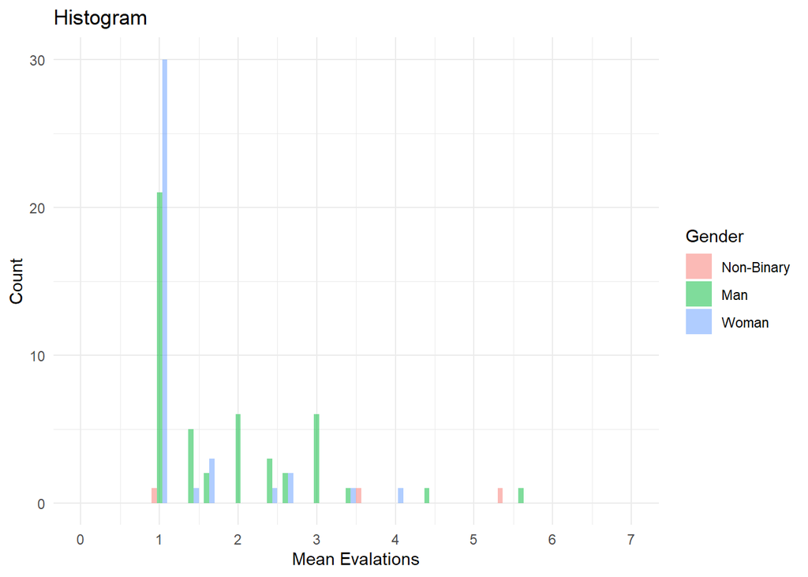

```r
data_processed_after_exclusions$gender <- factor(data_processed_after_exclusions$gender, levels = c("nonbinary", "male", "female"))

#histogramm

ggplot(data_processed_after_exclusions, aes(x = mean_evaluation, fill = gender)) +
  geom_histogram(alpha    = 0.5,
                 position = "dodge",
                 binwidth = .2)+
                 # alpha    = 0.5,
                 # position = "dodge") +
  scale_x_continuous(breaks = pretty_breaks(n = 7)) +
  coord_cartesian(xlim = c(0, 7)) +
    scale_fill_discrete(name      = "Gender",
                      labels    = c("Non-Binary",
                                    "Man",
                                    "Woman"))+
  labs(title                    = "Histogram",
       x                        = "Mean Evalations",
       y                        = "Count") +
  theme_minimal()
```

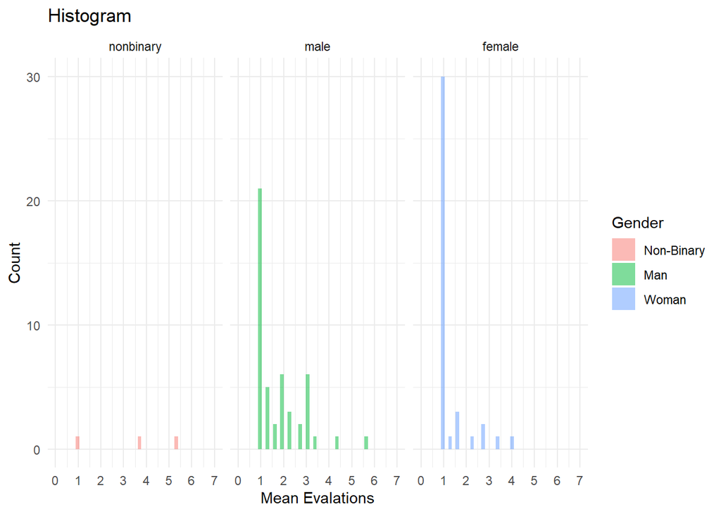

```r
ggplot(data_processed_after_exclusions, aes(x = mean_evaluation, fill = gender)) +
  geom_histogram(alpha    = 0.5,
                  position = "dodge",
                 )+#binwidth = 5,
                 # alpha    = 0.5,
                 # position = "dodge") +
  scale_x_continuous(breaks = pretty_breaks(n = 7)) +
  coord_cartesian(xlim = c(0, 7)) +
    scale_fill_discrete(name      = "Gender",
                      labels    = c("Non-Binary",
                                    "Man",
                                    "Woman"))+
  labs(title                    = "Histogram",
       x                        = "Mean Evalations",
       y                        = "Count") +
  facet_grid(~gender)+
  theme_minimal()
```

[figure not shown]

```r
#violin

ggplot(data_processed_after_exclusions, aes(x    = gender, y    = mean_evaluation, fill = gender)) +
  geom_flat_violin(draw_quantiles = .5,
              trim           = TRUE,
              alpha          = 0.5,) +
  scale_y_continuous(breaks  = pretty_breaks(n = 7)) +
  coord_cartesian(ylim       = c(0, 7)) +
    scale_fill_discrete(name      = "Gender",
                      labels    = c("Non-Binary",
                                    "Man",
                                    "Woman"))+
  labs(title                    = "Histogram",
       x                        = "Mean Evalations",
       y                        = "Count") +
  theme_minimal()
```

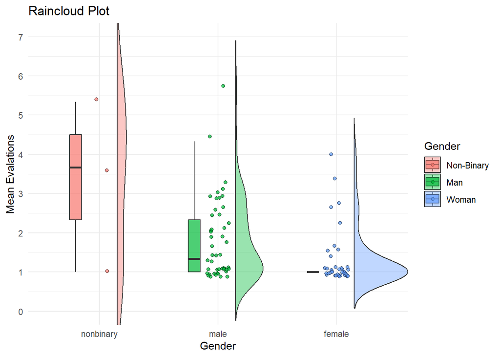

```r
#raincloud

rain_height <- .1

ggplot(data_processed_after_exclusions, aes(x = gender, y = mean_evaluation, fill = gender)) +
  geom_boxplot(width         = 0.1,
               outlier.shape = NA,
               position      = position_nudge(x      = -0.2),
               alpha         = .7) +
  geom_point(position        = position_jitter(width = .1),
             aes(color       = gender),
             alpha           = .75,
             color           = "black",
             shape           = 21) +
  geom_flat_violin(trim=FALSE, alpha = 0.4,
  position = position_nudge(x = rain_height+.05)) +
  scale_y_continuous(breaks  = pretty_breaks(n = 7)) +
  coord_cartesian(ylim       = c(0, 7)) +
    scale_fill_discrete(name      = "Gender",
                      labels    = c("Non-Binary",
                                    "Man",
                                    "Woman"))+
  labs(title                    = "Raincloud Plot",
       x                        = "Gender",
       y                        = "Mean Evalations") +
  theme_minimal()
```

### Test

run an appropriate test. Below the output, print an interpretation of the results generated by the ‘easystats’ package [report](https://easystats.github.io/report/). I.e., use `report::report()`.

```r
# install.packages("report")
# install.packages("remotes")
# remotes::install_github("easystats/report") # You only need to do that once
library(report)

model_amp <- lm(AMP_score ~ gender_numeric, data = data_processed_after_exclusions)
report(model_amp)
```

```
## We fitted a linear model (estimated using OLS) to predict AMP_score with
## gender_numeric (formula: AMP_score ~ gender_numeric). The model explains a
## statistically not significant and very weak proportion of variance (R2 =
## 1.15e-06, F(1, 88) = 1.02e-04, p = 0.992, adj. R2 = -0.01). The model's
## intercept, corresponding to gender_numeric = 0, is at 0.58 (95% CI [0.52,
## 0.64], t(88) = 19.43, p < .001). Within this model:
##
##   - The effect of gender numeric is statistically non-significant and negative
## (beta = -4.13e-04, 95% CI [-0.08, 0.08], t(88) = -0.01, p = 0.992; Std. beta =
## -1.07e-03, 95% CI [-0.21, 0.21])
##
## Standardized parameters were obtained by fitting the model on a standardized
## version of the dataset. 95% Confidence Intervals (CIs) and p-values were
## computed using a Wald t-distribution approximation.
```

## Combining plots

Combine plots using the library [patchwork](https://patchwork.data-imaginist.com/).

Combine at least three of the above plots into one.

```r
# # install.packages("devtools")
# devtools::install_github("thomasp85/patchwork")


library(patchwork)

p1 <- ggplot(data_processed_after_exclusions, aes(x = gender, y = mean_evaluation, fill = gender)) +
  geom_boxplot(width         = 0.1,
               outlier.shape = NA,
               position      = position_nudge(x      = -0.2),
               alpha         = .7) +
  geom_point(position        = position_jitter(width = .1),
             aes(color       = gender),
             alpha           = .75,
             color           = "black",
             shape           = 21) +
  geom_flat_violin(trim=FALSE, alpha = 0.4,
  position = position_nudge(x = rain_height+.05)) +
  scale_y_continuous(breaks  = pretty_breaks(n = 7)) +
  coord_cartesian(ylim       = c(0, 7)) +
     scale_fill_discrete(name      = "Gender",
                      labels    = c("Female",
                                    "Male",
                                    "Non-Binary"))+
  labs(title                    = "Raincloud Plot",
       x                        = "Gender",
       y                        = "Mean Evalations")
  theme_minimal()
```

[output not shown]

[output not shown]

```r
p2 <- ggplot(data_processed_after_exclusions, aes(x    = gender, y    = mean_evaluation, fill = gender)) +
  geom_flat_violin(draw_quantiles = .5,
              trim           = TRUE,
              alpha          = 0.5,) +
  scale_y_continuous(breaks  = pretty_breaks(n = 7)) +
  coord_cartesian(ylim       = c(0, 7)) +
   scale_fill_discrete(name      = "Gender",
                      labels    = c("Female",
                                    "Male",
                                    "Non-Binary"))+
  labs(title                    = "Violin Plot of Mean Evaluation",
       x                        = "Mean Evalations",
       y                        = "Count")
  theme_minimal()
```

[output not shown]

[output not shown]

[figure not shown]

```r
p3 <- ggplot(data_processed_after_exclusions, aes(x = mean_evaluation, fill = gender)) +
  geom_histogram(alpha    = 0.5,
                  position = "dodge",
                 )+#binwidth = 5,
                 # alpha    = 0.5,
                 # position = "dodge") +
  scale_x_continuous(breaks = pretty_breaks(n = 7)) +
  coord_cartesian(xlim = c(0, 7)) +
    scale_fill_discrete(name      = "Gender",
                      labels    = c("Female",
                                    "Male",
                                    "Non-Binary"))+
  labs(title                    = "Histogram",
       x                        = "Mean Evalations",
       y                        = "Count") +
  facet_grid(~gender)+
  theme_minimal()

combined_plots <- p1 + p2 + p3

combined_plots
```

## Saving plots

Save plots to disk with `ggsave()`

Save the above combined plot to disk as both .png and .pdf. Ensure the png has at least 300dpi resolution.

```r
ggsave("combined_plots.png", combined_plots, path = "../data/processed/", width = 20, height = 10)
```